# Tidy Models template

Peter Boshe

2022-06-18

# Context

We are going to model the data in a way that we are able to predict the count of bottles

## load clean data

```r
library(tidymodels)
library(tidyverse)
library(doMC)
library(poissonreg)
tidymodels_prefer(quiet = TRUE)

# parameters

   #input
file_raw <- here::here("docs/data/clean_waste_base_data.rds")

# set theme

theme_set(theme_bw())
```

## E.D.A

```r
waste_df <- read_rds(file_raw)



#check percent of bottlecount is 0
# mean(waste_df$bottle_count < 1)

# relation between amount and bottle count

# correlation
# cor(waste_df$amount, waste_df$bottle_count)

# table(waste_df$product_category, waste_df$scan_country)
# table(waste_df$product_category, waste_df$manufacturer_country)


## Cutting waste_df$amount into waste_df$amount_rec
waste_df$amount_rec <- cut(waste_df$amount,
  include.lowest = TRUE,
  right = FALSE,
  dig.lab = 4,
  breaks = c(0, 500, 1000, 2000, 5000, 20000)
)

glimpse(waste_df)
```

```
## Rows: 10,694
## Columns: 12
## $ batch                <fct> 1, 1, 1, 1, 1, 1, 1, 1, 1, 1, 1, 1, 1, 1, 1, 1, 1…
## $ year                 <fct> 2021, 2021, 2021, 2021, 2021, 2021, 2021, 2021, 2…
## $ month                <fct> 03, 03, 03, 03, 03, 03, 03, 03, 03, 03, 03, 03, 0…
## $ product_category     <fct> carbonated drink, domestic products, water, water…
## $ product_label        <chr> "vimto gasificado", "anti-bac all purpose cleaner…
## $ brand_name           <fct> vimto, method, água de namaacha, bonaqua, fanta, …
## $ manufacturer_country <fct> gb, us, mz, us, us, us, us, gb, uk, uk, gb, uk, j…
## $ scan_country         <fct> mz, gb, mz, mz, mz, mz, mz, gb, mz, gb, gb, gb, g…
## $ amount               <dbl> 350, 828, 5000, 500, 280, 280, 280, 500, 750, 500…
## $ units                <fct> ml, ml, ml, ml, ml, ml, ml, ml, ml, ml, ml, ml, m…
## $ bottle_count         <dbl> 1, 1, 1, 9, 6, 3, 17, 1, 2, 1, 1, 1, 1, 1, 20, 2,…
## $ amount_rec           <fct> "[0,500)", "[500,1000)", "[5000,2e+04]", "[500,10…
```

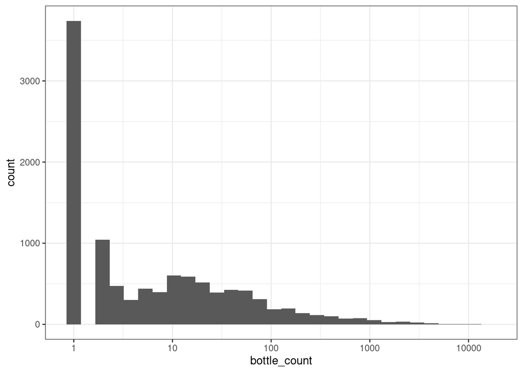

```r
# table(waste_df$product_category, waste_df$amount_rec)


# plot histogram

waste_df |>
  ggplot(aes(bottle_count)) +
  geom_histogram() +
  scale_x_log10()
```

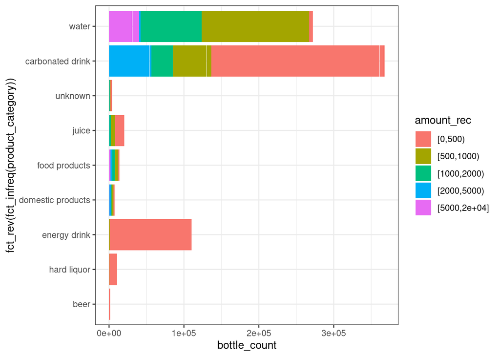

```r
# bar plot of product category and bottlecount
waste_df |>
  group_by(product_category) |>
  arrange(desc(bottle_count)) |>
  ungroup() |>
ggplot(aes(bottle_count, fct_rev(fct_infreq(product_category)),  fill = amount_rec)) +
  geom_col()
```

- we have had to transform the bottle count variable by log base of 10 since the distribution is skewed
- we have no zero counts due to our cleaning pipeline
- we are goint to uses a regular poisson regression, as opposed to the zero inflated poisson (ZIP) version which is a mixed effect model

however let’s review the definition of poisson distribution as per the oracle(wikipedia)

**Poisson distribution**

In probability theory and statistics, the Poisson distribution is a discrete probability distribution that expresses the probability of a given number of events occurring in a fixed interval of time or space if these events occur with a known constant mean rate and independently of the time since the last event.

Our data is of time series nature, I am not sure my previous decision to go with poisson distribution is justified.

hmm… but then again `batch` is a categorical variable and can be treated as such

**approach 1**

we are going to first neglect the effect of the time series

## Data allocation

```r
waste_df <- waste_df |>
  mutate(batch = as.numeric(batch)) |>
  arrange(batch) %>%
  mutate(.row = row_number()) # to simplify indexing
waste_df
```

```
## # A tibble: 10,694 × 13
##    batch year  month product_category  product_label brand_name manufacturer_co…
##    <dbl> <fct> <fct> <fct>             <chr>         <fct>      <fct>
##  1     1 2021  03    carbonated drink  vimto gasifi… vimto      gb
##  2     1 2021  03    domestic products anti-bac all… method     us
##  3     1 2021  03    water             agua mineral  água de n… mz
##  4     1 2021  03    water             bonaqua mine… bonaqua    us
##  5     1 2021  03    carbonated drink  fanta litchi  fanta      us
##  6     1 2021  03    carbonated drink  fanta orange  fanta      us
##  7     1 2021  03    carbonated drink  coke zero     coca-cola  us
##  8     1 2021  03    carbonated drink  carbonated s… irn-bru    gb
##  9     1 2021  03    hard liquor       18 year old … glenfiddi… uk
## 10     1 2021  03    water             still spring… ice valley uk
## # … with 10,684 more rows, and 6 more variables: scan_country <fct>,
## #   amount <dbl>, units <fct>, bottle_count <dbl>, amount_rec <fct>, .row <int>
```

```r
# inspect the proportion of the split if we split by  batch
split_prop <- (last(which(waste_df$batch <= 13))) / nrow(waste_df)

indices <-
  list(analysis   = waste_df$.row[waste_df$batch <= 13],
       assessment = waste_df$.row[waste_df$batch >  13]
  )

waste_split <- make_splits(indices, waste_df %>% select(-.row))
waste_train <- training(waste_split)
waste_test <- testing(waste_split)


# folds for cross validation

waste_folds <- vfold_cv(waste_train,v = 20)
```

## feature engineering recipes

- categorical data will need to be encoded for the poisson regression method

```r
# recipe for poisson reg
waste_rec <- recipe(bottle_count ~ batch + product_category + brand_name + manufacturer_country + scan_country + amount + units + amount_rec, data = waste_train) |>
  step_novel(all_nominal_predictors()) |>
  step_dummy(all_nominal_predictors()) |>
  step_nzv(all_predictors()) |>
  step_normalize(all_numeric_predictors())

# simple recipe for random forest
model_vars <- workflow_variables(outcomes = bottle_count,
                                 predictors = everything())
```

## calling all models

```r
poisson_reg_glm_spec <-
  poisson_reg() %>%
  set_engine('glm')

rand_forest_ranger_spec <-
  rand_forest(mtry = tune(), min_n = tune()) %>%
  set_engine('ranger') %>%
  set_mode('regression')
```

## setting our workflows

```r
poisson_wf <- workflow_set(list(basic = waste_rec), list(poisson = poisson_reg_glm_spec))

randforest_wf <- workflow_set(list(simple = model_vars), list(randforest = rand_forest_ranger_spec))

# combining our workflows
all_wflows <-
  bind_rows(poisson_wf, randforest_wf)
all_wflows
```

```
## # A workflow set/tibble: 2 × 4
##   wflow_id          info             option    result
##   <chr>             <list>           <list>    <list>
## 1 basic_poisson     <tibble [1 × 4]> <opts[0]> <list [0]>
## 2 simple_randforest <tibble [1 × 4]> <opts[0]> <list [0]>
```

## tuning our parameters

```r
ctrl <- control_grid(save_pred = TRUE,
                     save_workflow = TRUE)

doMC::registerDoMC(cores = 8)

full_res_time <-  system.time(
  grid_results <-
  all_wflows |>
  workflow_map(
    "tune_grid",
    seed = 123,
    verbose = TRUE,
    grid = 25,
    resamples = waste_folds,
    control = ctrl
  )
)
```

```
## i    No tuning parameters. `fit_resamples()` will be attempted
```

```
## i 1 of 2 resampling: basic_poisson
```

```
## ✔ 1 of 2 resampling: basic_poisson (16.2s)
```

```
## i 2 of 2 tuning:     simple_randforest
```

```
## i Creating pre-processing data to finalize unknown parameter: mtry
```

```
## ✔ 2 of 2 tuning:     simple_randforest (6m 8.9s)
```

```r
registerDoSEQ()
BRRR::skrrrahh(44)

# takes 6 and a half minutes
```

## evaluating our models

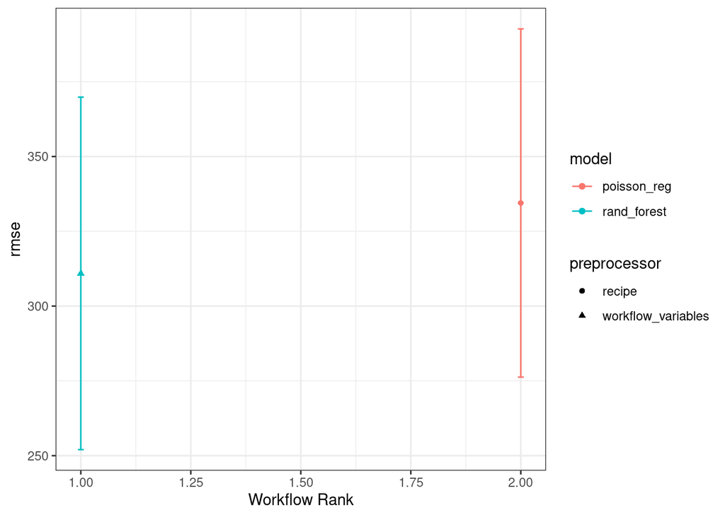

```r
# metrics <- collect_metrics(grid_results)

(autoplot(
   grid_results,
   rank_metric = "rmse",
   metric = "rmse",
   select_best = TRUE
))
```

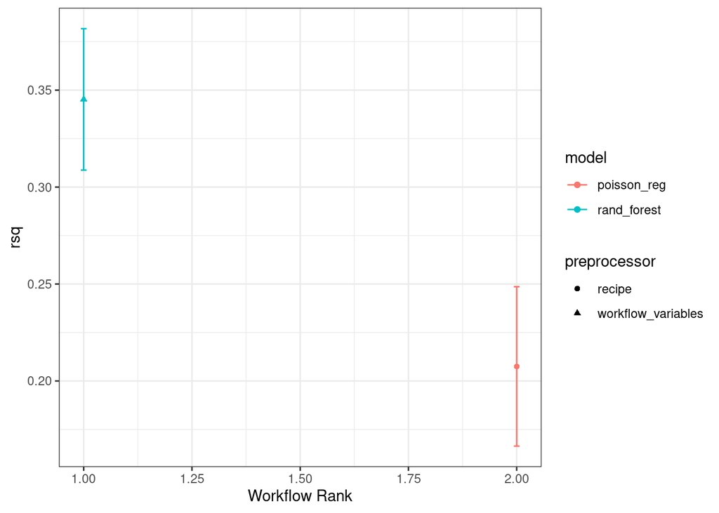

```r
(autoplot(
   grid_results,
   rank_metric = "rsq",
   metric = "rsq",
   select_best = TRUE
))
```

```r
# function does not work
# grid_results |> show_best(metric = "rmse")
```